# Project proposal

Wen Du

```r
library(tidyverse)
library(broom)
```

## 1. Introduction

This project uses a soil carbon dataset derived from McNicol et al. (2019), a published study of soil organic carbon stocks in the North Pacific coastal temperate rainforest. The study region spans southeast Alaska and coastal British Columbia, and the original research compiled more than 1,300 soil profiles (pedons) to estimate soil organic carbon stocks to 1 m depth. Soil organic carbon is an important component of the global carbon cycle, so understanding how it varies across soil types can help improve our understanding of carbon storage and ecosystem processes.

In this proposal, I ask whether mean soil organic carbon differs between mineral and organic soils at the pedon level. The response variable is total carbon to 1 m depth (total_c_1m), and the grouping variable is soil type (mineral vs. organic). This question is motivated by the expectation that organic soils typically store more carbon, although initial exploration suggests the pattern may be more complex.

In addition to this primary question, I will also explore how soil carbon varies across different soil orders, and whether there is a relationship between soil carbon and latitude. These additional questions allow for the application of a broader set of statistical methods, including ANOVA and linear regression, and help provide a more comprehensive understanding of the factors influencing soil carbon storage.

Because the dataset is structured at the horizon level (each row represents a soil horizon), multiple observations correspond to a single pedon. Therefore, the analysis is conducted at the pedon level so that each soil profile contributes one independent observation.

## 2. Data

```r
# load data
df <- read_csv("../data/data_final_project.csv")
# basic structure
glimpse(df)

# check soil horizon types
df %>%
  count(horizon_type)
```

[output not shown]

The dataset contains 6,868 observations and 26 variables. Each row represents a soil horizon, meaning that multiple rows correspond to a single pedon. Key variables include pedon_id (soil profile identifier), horizon_type (mineral or organic), and total_c_1m (total soil carbon to 1 m depth). Because the research question focuses on carbon storage per soil profile, the analysis must be conducted at the pedon level rather than the horizon level. Therefore, each pedon represents the unit of analysis, rather than individual soil horizons.

## 3. Data analysis plan

```r
# keep one carbon value per pedon
pedon_carbon <- df %>%
  filter(pedon_start == TRUE) %>%
  select(pedon_id, total_c_1m)

# classify pedons based on whether they contain organic horizons
pedon_type <- df %>%
  select(pedon_id, horizon_type) %>%
  mutate(horizon_type = tolower(horizon_type)) %>%
  group_by(pedon_id) %>%
  summarise(
    pedon_type = if_else(any(horizon_type == "organic", na.rm = TRUE),
                         "organic", "mineral"),
    .groups = "drop"
  )

# combine datasets
final_df <- left_join(pedon_carbon, pedon_type, by = "pedon_id")

# check group sizes
final_df %>%
  count(pedon_type)
```

```
## # A tibble: 2 × 2
##   pedon_type     n
##   <chr>      <int>
## 1 mineral      294
## 2 organic      989
```

The data are aggregated so that each pedon contributes one observation, ensuring that the unit of analysis is consistent and that observations are independent.

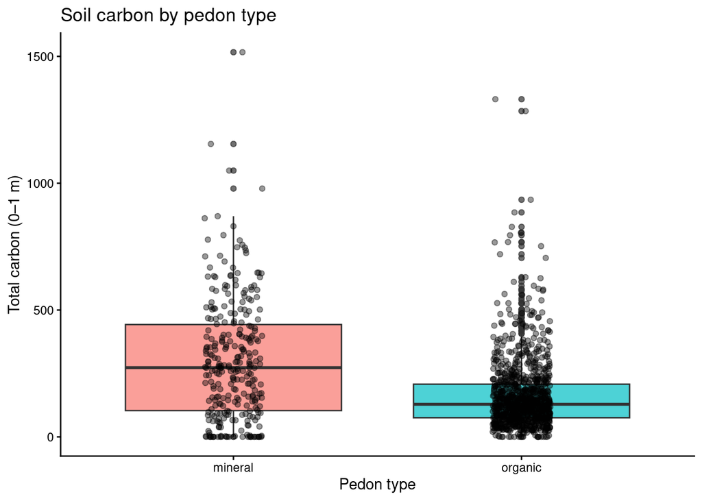

```r
# exploratory plot
ggplot(final_df, aes(x = pedon_type, y = total_c_1m, fill = pedon_type)) +
  geom_boxplot(alpha = 0.7) +
  geom_jitter(width = 0.1, alpha = 0.4) +
  theme_classic() +
  labs(
    title = "Soil carbon by pedon type",
    x = "Pedon type",
    y = "Total carbon (0–1 m)"
  ) +
  theme(legend.position = "none")
```

The boxplot compares soil carbon between mineral and organic soils. The individual data points are shown to illustrate the distribution and variability within each group, providing additional context beyond the summary statistics displayed by the boxplot.

Mineral soils appear to have higher median carbon values, although there is substantial variability and overlap between groups. This pattern is somewhat unexpected and suggests that the relationship between soil type and carbon storage may be more complex than initially assumed.

```r
# t-test
t.test(total_c_1m ~ pedon_type, data = final_df) %>%
  tidy()
```

```
## # A tibble: 1 × 10
##   estimate estimate1 estimate2 statistic  p.value parameter conf.low conf.high
##      <dbl>     <dbl>     <dbl>     <dbl>    <dbl>     <dbl>    <dbl>     <dbl>
## 1     136.      300.      164.      9.35 9.67e-19      355.     108.      165.
## # ℹ 2 more variables: method <chr>, alternative <chr>
```

This analysis compares the mean of a continuous variable (total_c_1m) between two groups (mineral vs. organic soils), so a two-sample t-test is appropriate. The key results from this test include the group means, the mean difference, a confidence interval, and a p-value to evaluate whether the observed difference in group means is statistically significant.

Based on the exploratory results, mineral soils appear to have higher carbon values, and statistical testing is used to evaluate whether this observed difference is statistically significant.

The additional questions will be explored further in the full analysis.

## Reference

McNicol, G., Bulmer, C., D’Amore, D., Sanborn, P., Saunders, S., Giesbrecht, I., Gonzalez Arriola, S., Bidlack, A., Butman, D., & Buma, B. (2019). Large, climate-sensitive soil carbon stocks mapped with pedology-informed machine learning in the North Pacific coastal temperate rainforest. Environmental Research Letters, 14, 014004. https://doi.org/10.1088/1748-9326/aaed52